# Machine Learning Assignment

Emily Jones

## Project Goal

I will apply Machine Learning techniques to predict the manner in which a study participant performed weight lifting exercises.

I am using data from an existing study. Citation for this dataset is

Velloso, E.; Bulling, A.; Gellersen, H.; Ugulino, W.; Fuks, H. Qualitative Activity Recognition of Weight Lifting Exercises. Proceedings of 4th International Conference in Cooperation with SIGCHI (Augmented Human ’13) . Stuttgart, Germany: ACM SIGCHI, 2013.

Read more: http://groupware.les.inf.puc-rio.br/har#ixzz3HCvitx6t

## Data Processing

### First load the data, and any libraries needed for analysis

```r
library(caret)
```

```r
library(AppliedPredictiveModeling)
library(ggplot2)
library(randomForest)
library(RCurl)
pml.testing <- read.csv(url("http://d396qusza40orc.cloudfront.net/predmachlearn/pml-testing.csv"))
pml.training <- read.csv(url("http://d396qusza40orc.cloudfront.net/predmachlearn/pml-training.csv"))
```

### Reduce the variables I am looking at.

Remove

- non-numeic columns
- columns with missing data
- first 7 columns with timesstamp and other data not pertinent

Add the classe column back in (It is at column 160)

```r
# Table is sparse, choose only numeric with no missing values, exclude for 7 columns with datestamps and # windows. They will not affect the result

nums <- sapply(pml.training, is.numeric)
miss<-sapply(pml.training,function(x) any(is.na(x)))

which(colnames(training)=="classe")
```

[output not shown]

```r
cols<-nums & !miss
cols[160]<-TRUE
cols[1:7]<-FALSE

# subtrain is now the columns from pml.training I am interested
subtrain <-pml.training[,cols]
```

## Fitting a model

I used a Random Tree Model on the remaining columns. Random Forests do well with prediction and give estimates of what variables are of most importance. They are also not sensitive to overfitting

### Create training and testing subsets from reduced training data

In order to see how accurately the proposed model will generalize to the independent testing data set (cross-validation), the data is partitioned into a training subset and validation subset, using a 75/25 split.

I fit the Random Forest model against the training subset

```r
inTrain = createDataPartition(subtrain$classe, p = 3/4)[[1]]
training = subtrain[ inTrain,]
testing = subtrain[-inTrain,]

fit <- randomForest(training$classe ~ ., data=training, importance = TRUE)

print(fit)
```

```
##
## Call:
##  randomForest(formula = training$classe ~ ., data = training,      importance = TRUE)
##                Type of random forest: classification
##                      Number of trees: 500
## No. of variables tried at each split: 7
##
##         OOB estimate of  error rate: 0.43%
## Confusion matrix:
##      A    B    C    D    E class.error
## A 4180    3    1    0    1    0.001195
## B   13 2833    2    0    0    0.005267
## C    0   14 2553    0    0    0.005454
## D    0    0   25 2386    1    0.010779
## E    0    0    1    3 2702    0.001478
```

### Evaluate model against the testing subset

```r
confusionMatrix(testing$classe,predict(fit,testing))
```

```
## Confusion Matrix and Statistics
##
##           Reference
## Prediction    A    B    C    D    E
##          A 1395    0    0    0    0
##          B    2  943    4    0    0
##          C    0    0  855    0    0
##          D    0    0    7  797    0
##          E    0    0    0    1  900
##
## Overall Statistics
##
##                Accuracy : 0.997
##                  95% CI : (0.995, 0.998)
##     No Information Rate : 0.285
##     P-Value [Acc > NIR] : <2e-16
##
##                   Kappa : 0.996
##  Mcnemar's Test P-Value : NA
##
## Statistics by Class:
##
##                      Class: A Class: B Class: C Class: D Class: E
## Sensitivity             0.999    1.000    0.987    0.999    1.000
## Specificity             1.000    0.998    1.000    0.998    1.000
## Pos Pred Value          1.000    0.994    1.000    0.991    0.999
## Neg Pred Value          0.999    1.000    0.997    1.000    1.000
## Prevalence              0.285    0.192    0.177    0.163    0.184
## Detection Rate          0.284    0.192    0.174    0.163    0.184
## Detection Prevalence    0.284    0.194    0.174    0.164    0.184
## Balanced Accuracy       0.999    0.999    0.994    0.999    1.000
```

## Interpretation of the Model

Now use Random Tree tools to evaluate most influential factor.

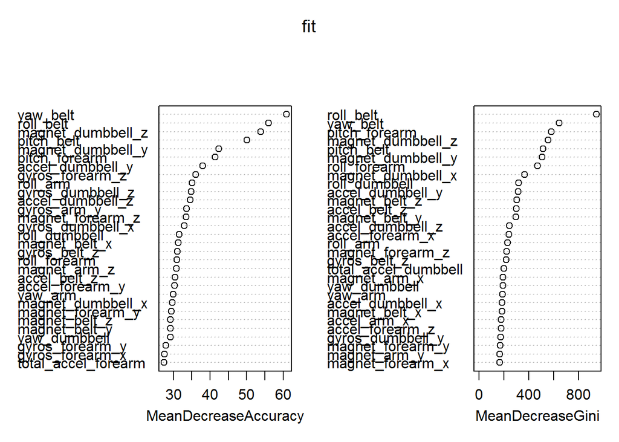

```r
varImpPlot(fit)
```

The top factors seem to be roll_belt, yaw_belt, pitch_forearm adn magnet_dumbell_z

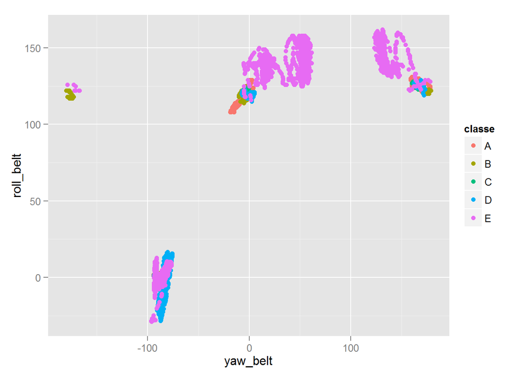

```r
qplot(yaw_belt,roll_belt,colour=classe,data=training)
```

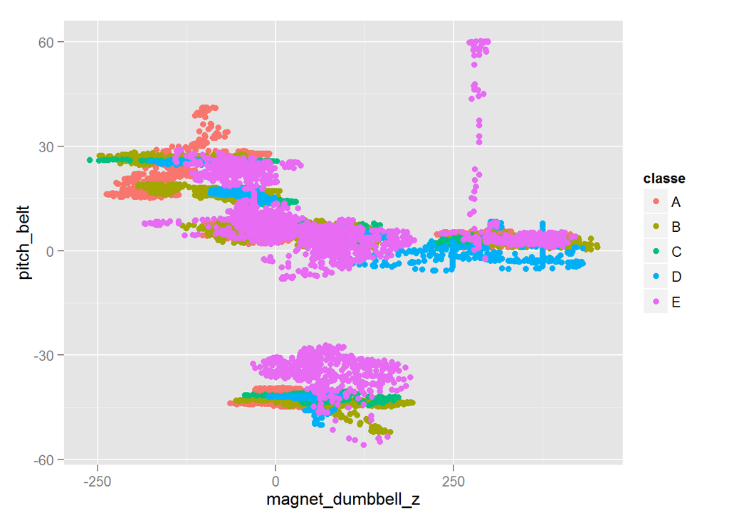

```r
qplot(magnet_dumbbell_z,pitch_belt,colour=classe,data=training)
```

The coding for the responses: A-E is as follows:

Six young health participants were asked to perform one set of 10 repetitions of the Unilateral Dumbbell Biceps Curl in five different fashions:

A: exactly according to the specification B: throwing the elbows to the front C: lifting the dumbbell only halfway D: lowering the dumbbell only halfway E: throwing the hips to the front

## Make predictions against the test set

```r
subtesting <- pml.testing[,cols]

answers = predict(fit, subtesting)

print(answers)
```

```
##  1  2  3  4  5  6  7  8  9 10 11 12 13 14 15 16 17 18 19 20
##  B  A  B  A  A  E  D  B  A  A  B  C  B  A  E  E  A  B  B  B
## Levels: A B C D E
```

```r
pml_write_files = function(x){
    n = length(x)
    for(i in 1:n){
        filename = paste0("problem_id_",i,".txt")
        write.table(x[i],file=filename,quote=FALSE,row.names=FALSE,col.names=FALSE)
    }
}

pml_write_files(answers)
```